# My R Markdown Primer

Premitha

2025-11-09

# Introduction

R Markdown is a powerful tool for combining narrative text, code, and output in a single document. It allows analysts and researchers to create **reproducible reports**, where the analysis can be rerun with fresh data and results automatically updated. In bioinformatics, this is especially useful for analyzing **gene expression data**, as we can document our workflow and update results automatically. For more details on using R Markdown see http://rmarkdown.rstudio.com.

# Narrative Section

RNA-Seq experiments generate massive amounts of data representing **gene expression levels** across samples.  
Bioinformaticians often need to summarize, visualize, and statistically test this data to find **differentially expressed genes**.

# LaTeX Math Examples

Bioinformatics often uses **mathematical models** to describe biological processes. For example, a common equation in genetics is **Hardy-Weinberg equilibrium**: Inline: $p^2 + 2pq + q^2 = 1$

Displayed:

$$p^2 + 2pq + q^2 = 1$$

Where:

- $p$ = frequency of allele A
- $q$ = frequency of allele a

```r
# Load Libraries and Data
# Install Bioconductor if needed
if (!requireNamespace("BiocManager", quietly = TRUE))
  install.packages("BiocManager")
BiocManager::install("DESeq2")
# Load necessary libraries
BiocManager::install("airway", update = FALSE, ask3 = FALSE)
library(airway)
```

```r
library(DESeq2)
library(ggplot2)
library(tidyverse)
# Load the airway dataset
data("airway")
airway
```

```
## class: RangedSummarizedExperiment
## dim: 63677 8
## metadata(1): ''
## assays(1): counts
## rownames(63677): ENSG00000000003 ENSG00000000005 ... ENSG00000273492
##   ENSG00000273493
## rowData names(10): gene_id gene_name ... seq_coord_system symbol
## colnames(8): SRR1039508 SRR1039509 ... SRR1039520 SRR1039521
## colData names(9): SampleName cell ... Sample BioSample
```

```r
# Explore the Dataset
# Convert to a DESeq2 object
dds <- DESeqDataSet(airway, design = ~ cell + dex)
# Check counts for the first 6 genes
head(counts(dds))
```

```
##                 SRR1039508 SRR1039509 SRR1039512 SRR1039513 SRR1039516
## ENSG00000000003        679        448        873        408       1138
## ENSG00000000005          0          0          0          0          0
## ENSG00000000419        467        515        621        365        587
## ENSG00000000457        260        211        263        164        245
## ENSG00000000460         60         55         40         35         78
## ENSG00000000938          0          0          2          0          1
##                 SRR1039517 SRR1039520 SRR1039521
## ENSG00000000003       1047        770        572
## ENSG00000000005          0          0          0
## ENSG00000000419        799        417        508
## ENSG00000000457        331        233        229
## ENSG00000000460         63         76         60
## ENSG00000000938          0          0          0
```

```r
# Simple Analysis: Normalization
# Normalize counts using DESeq2's variance stabilizing transformation (VST)
vsd <- vst(dds, blind = FALSE)

# Summary statistics for a few genes
assay(vsd)[1:6,]
```

```
##                 SRR1039508 SRR1039509 SRR1039512 SRR1039513 SRR1039516
## ENSG00000000003   9.742074   9.430420   9.867626   9.645844  10.183143
## ENSG00000000005   6.681994   6.681994   6.681994   6.681994   6.681994
## ENSG00000000419   9.333668   9.581706   9.486145   9.523093   9.427283
## ENSG00000000457   8.765274   8.698448   8.651473   8.732426   8.592786
## ENSG00000000460   7.747624   7.771308   7.500109   7.690339   7.811612
## ENSG00000000938   6.681994   6.681994   6.867264   6.681994   6.813145
##                 SRR1039517 SRR1039520 SRR1039521
## ENSG00000000003   9.880416  10.010366   9.639782
## ENSG00000000005   6.681994   6.681994   6.681994
## ENSG00000000419   9.574860   9.325998   9.509246
## ENSG00000000457   8.702673   8.761945   8.724101
## ENSG00000000460   7.620755   7.935666   7.789372
## ENSG00000000938   6.681994   6.681994   6.681994
```

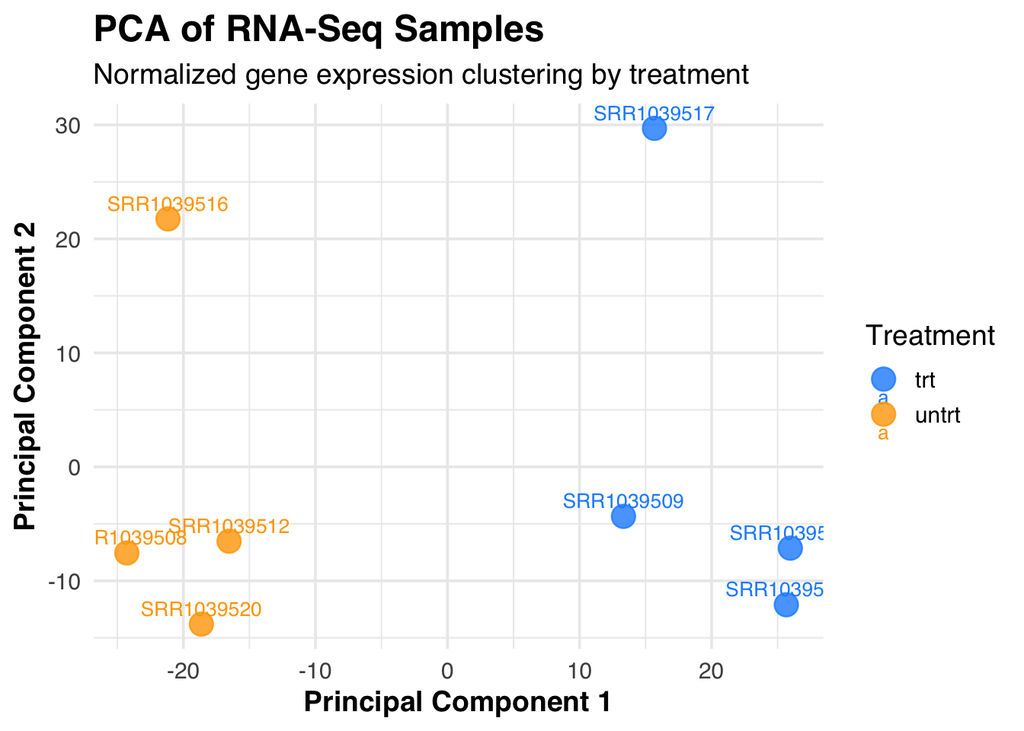

```r
# Visualization: PCA Plot
# Principal Component Analysis (PCA) to visualize samples
# PCA analysis
pca <- prcomp(t(assay(vsd)))
pca_data <- as.data.frame(pca$x)
pca_data$Sample <- colnames(vsd)
pca_data$Treatment <- colData(vsd)$dex

# Plot
library(ggplot2)
ggplot(pca_data, aes(PC1, PC2, color = Treatment, label = Sample)) +
  geom_point(size = 5, alpha = 0.8) +
  geom_text(vjust = -0.6, hjust = 0.5, size = 3.5) +
  theme_minimal(base_size = 14, base_family = "Helvetica") +
  labs(
    title = "PCA of RNA-Seq Samples",
    subtitle = "Normalized gene expression clustering by treatment",
    x = "Principal Component 1",
    y = "Principal Component 2"
  ) +
  scale_color_manual(values = c("dodgerblue", "orange")) +
  theme(
    plot.title = element_text(face = "bold", size = 18),
    plot.subtitle = element_text(size = 14),
    axis.title = element_text(face = "bold")
  )
```

# Reflection

Using R Markdown with bioinformatics datasets like RNA-Seq offers clear advantages:

- Reproducibility: All analysis steps are documented in one file.
- Integration of text, math, and code: Results are automatically linked with interpretations.
- Visualization: PCA plots and other figures are embedded directly.
- Workflow tracking: Easy to revisit and update analyses.

Compared to static reports, this approach reduces errors, improves clarity, and facilitates collaboration.

# Conclusion

This primer demonstrated: - Loading a real RNA-Seq dataset from Bioconductor. - Performing basic normalization and exploratory analysis. - Visualizing gene expression patterns using PCA. - Documenting a complete bioinformatics workflow in R Markdown.